# Lab 5: Interaction Contrasts with Two-way Factorial ANOVA

# 1. Introduction

This tutorial will walk through how to review and run a interaction contrast using two-way factorial ANOVA. We will produce descriptive statistics for checking ANOVA assumptions, run a two-way factorial ANOVA, code interaction contrasts, and produce effect sizes to address specified research questions.

**Note:** Much of the content for Lab 5 overlaps with code from the past several labs. To highlight new code and avoid redundancy, the code needed for complete evaluate assumptions and explore these data are not provided in this tutorial, but are still expected to be used in your write-up and analysis as appropriate. See lab keys from previous assignments to review code for the basic tenants of ANOVA.

This tutorial uses data from your textbook (see [‘Support Materials’ on the textbook webpage](https://www.routledge.com/Design-and-Analysis-in-Educational-Research-ANOVA-Designs-in-SPSS/Strunk-Mwavita/p/book/9781138361164); Bossaert et al., 2011), which focus on the social dimension of inclusion in education in different countries. The columns include the following information:

- `country`: name of country
- `soc_part`: social participation (score)
- `sen2`: students with special educational needs categorization

# 2. Reviewing the Data

We will load the packages and read in the data as we have previous labs.

```r
# Load necessary packages:
needs(tidyverse, rio, here, knitr, kableExtra, misty, janitor, rstatix, psych, misty)

df <- misty::read.sav(here("kamden-mwavita_data/factorial_ANOVA_Bossaert_et_al.sav"), use.value.labels = TRUE) %>%
  clean_names() %>%
  # Re-categorizing the groups within 'sen' for the purposes of simplifying instructions
  mutate(sen2 = recode_factor(sen,
                                 "Typically developing" = "Typically developing",
                                "Special Educational Needs" = "Special needs",
                                "Behavioral needs" = "Special needs",
                                "Other special needs" = "Special needs")) %>%
  select(1:2,4) # Selecting only the columns of data we'll use
```

Now, we run through the basic descriptive statistics. See Lab 4 for more information or explanations of this code and how to assess whether assumptions of ANOVA have been met, if needed.

```r
table(df$sen2)
```

```
##
## Typically developing        Special needs
##                 1117                  218
```

```r
table(df$country)
```

```
##
##     Belgium Netherlands      Norway
##         555         245         535
```

Summary table of the data with both variables: Notice that we do not have an equal number of cases among our groups.

```r
df %>%
  group_by(sen2, country) %>%
  summarise(n = n()) %>%
  spread(country, n)
```

```
## # A tibble: 2 × 4
## # Groups:   sen2 [2]
##   sen2                 Belgium Netherlands Norway
##   <fct>                  <int>       <int>  <int>
## 1 Typically developing     469         187    461
## 2 Special needs             86          58     74
```

Overall descriptive statistics – Make sure to interpret overall distribution statistics.

```r
describe(df)
```

```
##          vars    n mean   sd median trimmed  mad   min   max range skew
## soc_part    1 1335 3.88 2.19    3.9    3.89 2.10 -3.63 11.37    15 0.00
## country*    2 1335 1.99 0.90    2.0    1.98 1.48  1.00  3.00     2 0.03
## sen2*       3 1335 1.16 0.37    1.0    1.08 0.00  1.00  2.00     1 1.82
##          kurtosis   se
## soc_part     0.09 0.06
## country*    -1.78 0.02
## sen2*        1.31 0.01
```

Examining descriptive statistics for each IV by level.

```r
#Output for each level - sen2
describeBy(x = df$soc_part, group = df$sen2,
             mat = TRUE, data = df)
```

```
##     item               group1 vars    n     mean       sd   median  trimmed
## X11    1 Typically developing    1 1117 4.077323 2.165951 4.042455 4.079719
## X12    2        Special needs    1  218 2.881055 2.068132 3.094969 2.901493
##          mad       min      max    range        skew   kurtosis         se
## X11 2.102421 -3.628685 11.37383 15.00251  0.02195719  0.1011514 0.06480702
## X12 1.953231 -2.842356  7.65367 10.49603 -0.14124846 -0.2049044 0.14007159
```

```r
#Output for each level - country
describeBy(x = df$soc_part, group = df$country,
             mat = TRUE, data = df)
```

```
##     item      group1 vars   n     mean       sd   median  trimmed      mad
## X11    1     Belgium    1 555 4.070793 2.272759 4.179308 4.086875 2.304347
## X12    2 Netherlands    1 245 3.973959 2.265022 3.838034 3.977286 2.055381
## X13    3      Norway    1 535 3.643981 2.056824 3.693005 3.646557 1.940197
##           min      max    range          skew   kurtosis         se
## X11 -1.772008 11.37383 13.14583 -0.0400684496 -0.1557800 0.09647326
## X12 -3.628685 10.45541 14.08409 -0.0147263222  0.4329515 0.14470694
## X13 -2.842356 10.12549 12.96785  0.0001342598  0.1519874 0.08892424
```

### 2.1 Visually Inspecting the Data

#### 2.1.a Marginal Means Plots

Pulling from what we learned last week about marginal means as another way to summarize mean values, complete the following steps to compare the means with each other:  
**Step 1.** Extract means to examine group differences.

```r
means <- df %>% #creating new object (tibble) with the means
  group_by(sen2, country) %>% #grouping our results by our two independent variables, 'country' within levels of 'sen2'
  summarise(mean_soc_part = mean(soc_part)) #extract the mean of dependent variable
means #view new data
```

```
## # A tibble: 6 × 3
## # Groups:   sen2 [2]
##   sen2                 country     mean_soc_part
##   <fct>                <fct>               <dbl>
## 1 Typically developing Belgium              4.25
## 2 Typically developing Netherlands          4.18
## 3 Typically developing Norway               3.86
## 4 Special needs        Belgium              3.09
## 5 Special needs        Netherlands          3.31
## 6 Special needs        Norway               2.30
```

**Step 2.** Examine the means using a profile plot.  
As a reminder, you can change the aesthetics (`aes()`) of the graph above to represent the means to best represent the data and make them easy to interpret given your hypotheses/research questions.

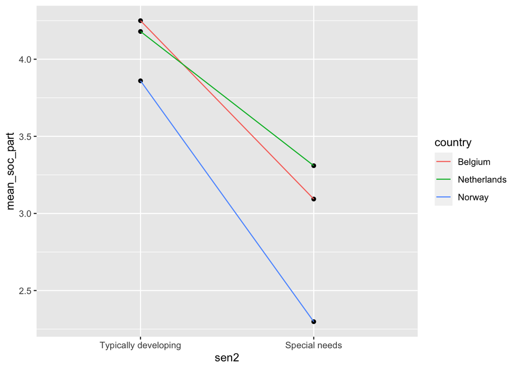

```r
# Graphical representation of means
means %>%
  ggplot(aes(sen2, mean_soc_part, group = country)) +
  geom_point() +
  geom_line(aes(color = country))
```

#### 2.1.b Boxplots

Another way to easily display the group differences of one IV by another.

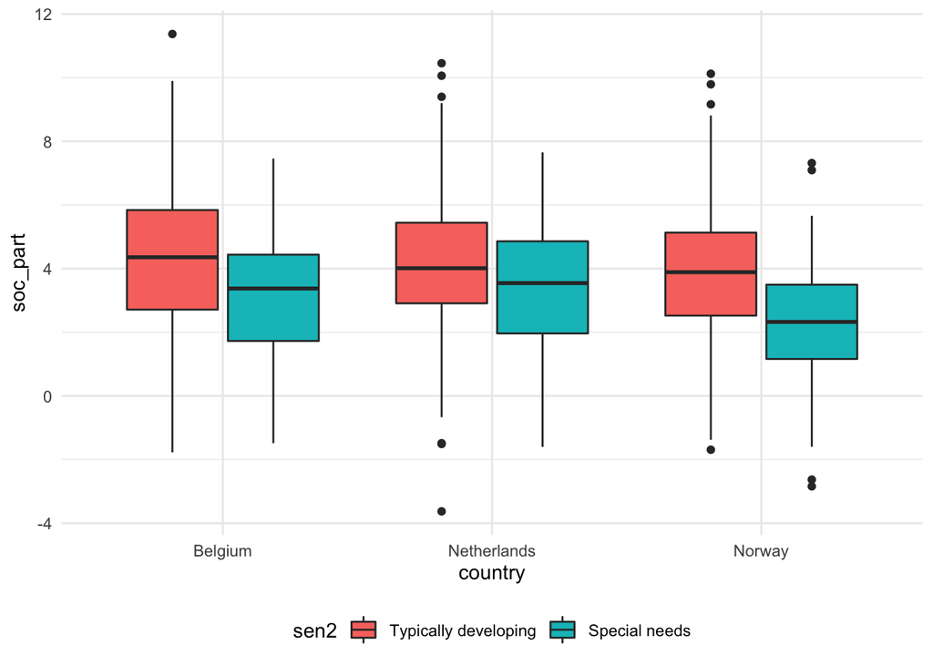

```r
df %>%
  ggplot(aes(x = country, y = soc_part, fill = sen2)) +
  geom_boxplot() +
  theme_minimal() +
  theme(legend.position="bottom")
```

# 3. Two-way Factorial ANOVA and Pairwise Comparisons

### 3.1 Run the two-way factorial ANOVA

We will now run our factorial ANOVA using the same code as in Lab 4. As a reminder, from our results, we see that there are significant main effects on *social participation* for *special educational needs* (*F*(1, 1329) = 54.04, *p* < .001) and *country* (*F*(2, 1329) = 7.00, *p* < .001), and the interaction effect between *special educational needs* and *country* was not significant (*F*(2, 1329) = 1.43, *p* = .239). Therefore, we do not find evidence that the effects of *special educational needs* on *social participation* differs between countries.

We will elaborate on the main effect and simple effects using the marginal means for the groups in the subsequent sections.

```r
anova_test(df, formula = soc_part ~ sen2 + country + sen2:country,
                 detailed = TRUE, type = 3, effect.size = "pes")
```

```
## Coefficient covariances computed by hccm()
```

```
## ANOVA Table (type III tests)
##
##         Effect      SSn      SSd DFn  DFd        F         p p<.05   pes
## 1  (Intercept) 8468.637 6086.286   1 1329 1849.210 6.91e-254     * 0.582
## 2         sen2  247.505 6086.286   1 1329   54.045  3.41e-13     * 0.039
## 3      country   64.095 6086.286   2 1329    6.998  9.48e-04     * 0.010
## 4 sen2:country   13.137 6086.286   2 1329    1.434  2.39e-01       0.002
```

### 3.2 Estimate Marginal Means

The code in this section allows us to dig deeper into our hypothesized model, where we can produce the means for groups and look at their pairwise comparisons. Following the steps below, similar to Lab 4, you will be able have a closer look at the main and simple effects for IVs on our DV. We will use the findings to develop *post-hoc* hypotheses to test in section “4. Factorial ANOVA Interaction Contrasts.”

```r
model <- lm(soc_part ~ sen2 + country, df) #remember 'sen2:country' represents the interaction effect in the model
```

**Step 2.** Extract the values/estimated for marginal means from the model (object we previously called `model` in Step 1), using the `emmeans` package and put into a new object (below called `means_1`). The output for this code, using `pairs()`, describes the means for `sen2` and conducts pairwise contrasts by `country`, our designated moderator variable.

```r
needs(emmeans)
means_1 <- emmeans(model, specs = "sen2", by = "country") #use the model to calculate means for sen2 grouped by country

pairs(means_1) # display the means produced by emmeans() in pairs
```

```
## country = Belgium:
##  contrast                             estimate    SE   df t.ratio p.value
##  Typically developing - Special needs     1.23 0.159 1331   7.720  <.0001
##
## country = Netherlands:
##  contrast                             estimate    SE   df t.ratio p.value
##  Typically developing - Special needs     1.23 0.159 1331   7.720  <.0001
##
## country = Norway:
##  contrast                             estimate    SE   df t.ratio p.value
##  Typically developing - Special needs     1.23 0.159 1331   7.720  <.0001
```

```r
means_2 <- emmeans(model, ~sen2*country) #use same model but use different specifications

pairs(means_2) #display means in pairs, unnested
```

```
##  contrast                                                        estimate    SE
##  Typically developing Belgium - Special needs Belgium             1.22940 0.159
##  Typically developing Belgium - Typically developing Netherlands -0.00371 0.165
##  Typically developing Belgium - Special needs Netherlands         1.22570 0.220
##  Typically developing Belgium - Typically developing Norway       0.44727 0.130
##  Typically developing Belgium - Special needs Norway              1.67667 0.207
##  Special needs Belgium - Typically developing Netherlands        -1.23311 0.238
##  Special needs Belgium - Special needs Netherlands               -0.00371 0.165
##  Special needs Belgium - Typically developing Norway             -0.78214 0.203
##  Special needs Belgium - Special needs Norway                     0.44727 0.130
##  Typically developing Netherlands - Special needs Netherlands     1.22940 0.159
##  Typically developing Netherlands - Typically developing Norway   0.45097 0.166
##  Typically developing Netherlands - Special needs Norway          1.68037 0.241
##  Special needs Netherlands - Typically developing Norway         -0.77843 0.219
##  Special needs Netherlands - Special needs Norway                 0.45097 0.166
##  Typically developing Norway - Special needs Norway               1.22940 0.159
##    df t.ratio p.value
##  1331   7.720  <.0001
##  1331  -0.023  1.0000
##  1331   5.575  <.0001
##  1331   3.448  0.0077
##  1331   8.083  <.0001
##  1331  -5.181  <.0001
##  1331  -0.023  1.0000
##  1331  -3.847  0.0017
##  1331   3.448  0.0077
##  1331   7.720  <.0001
##  1331   2.719  0.0722
##  1331   6.985  <.0001
##  1331  -3.557  0.0052
##  1331   2.719  0.0722
##  1331   7.720  <.0001
##
## P value adjustment: tukey method for comparing a family of 6 estimates
```

# 4. Factorial ANOVA Interaction Contrasts

In section 3, we answered the question of whether the effect of `sen2` on `soc_part` significantly differed between levels of `country`, finding no evidence to support our hypothesis. However, we can further probe our interactions by running *post-hoc* contrasts. Similar to what we practiced in Lab 3, we will apply *post-hoc* contrasts to extend our understanding of between group variance. Applying interaction contrasts will be the core of completing your analyses for Lab 5.

We will start by defining a *post-hoc* hypothesis based on the mean differences observed in the descriptive statistics and data visualizations:  
* Hypothesis: The mean level of ‘social participation’ for ‘typically developing’ and ‘special needs’ significantly differ between Norway vs. Belgium and the Netherlands.

### 4.1 Defining contrasts

Because this is a 2x3 two-way factorial ANOVA, we need to provide 6 contrast coefficients for each hypothesized contrast comparison, one for each combination between our two IVs. The code below has notes to clarify the contrast coefficient values.

```r
contrasts <- list(
  hyp1 = c(-1, -1, 2, 1, 1, -2)) # Hypothesis 1: contrasting social interaction scores of typically developing and spec. needs between Norway vs. Belgium and the Netherlands.

m <- contrast(means_2, contrasts, adjust = "holm")
test(m, joint = TRUE)
```

```
##  df1  df2 F.ratio p.value
##    1 1331  25.053  <.0001
```

Before we interpret the results of the interaction contrast, we need to calculate the new $\alpha$ threshold to correct for multiple comparisons inflating our Type 1 Familywise Error Rate. Counting the initial two-way factorial ANOVA and the *post-hoc* contrast, the new significance threshold for *p* is .025 (i.e., $\alpha$ = .05/2 tests = .025).

### 4.2 Effect Sizes

Calculate effect size with omega squared ($\omega^{2}$).

```r
#Let's calculate effect size with Omega
# First turn t-ratio into F-ratio by squaring it: t^2 = F
(5.005)^2
```

```
## [1] 25.05002
```

```r
# Fvalue = 25.05

needs(MOTE)
# Second, put in values accordingly:
omega.F(dfm = 1, dfe = 1331,
      Fvalue = 25.05, n = 1335, a = .025)
```

```
## $omega
## [1] 0.01769618
##
## $omegalow
## [1] 0.005211866
##
## $omegahigh
## [1] 0.03716371
##
## $dfm
## [1] 1
##
## $dfe
## [1] 1331
##
## $F
## [1] 25.05
##
## $p
## [1] 6.333788e-07
##
## $estimate
## [1] "$\\omega^2$ = 0.02, 97.5\\% CI [0.01, 0.04]"
##
## $statistic
## [1] "$F$(1, 1331) = 25.05, $p$ < .001"
```